| **CANADA COVID-19 Data Analysis** |
| --- |

| **1. Introduction** |
| --- |

| **1.1 Project Objective** |
| --- |

#### 1. Analyze Canadian COVID-19 data using the dataset from Johns Hopkins University.

#### 2. Compare the outcomes of COVID-19 responses using multiple visualization techniques.

#### 3. Employ cluster analysis to uncover inside relationship among different provinces.

| **1.2 Data Source** |
| --- |

#### 1. The data comes from the Johns Hopkins University COVID-19 dataset.

#### 2. JHU’s COVID-19 dataset is globally recognized as one of the most comprehensive sources.

#### 3. The dataset includes not only national-level data but also data at the state or provincial level and other detailed breakdowns.

| **1.3 Importing Packages** |
| --- |

```r
library(tidyverse)
library(lubridate)
library(cowplot)
library(ggthemes)
library(forecast)
library(knitr)
library(data.table)
library(leaflet)
library(tinytex)
library(kableExtra)
library(gridExtra)
library(dplyr)
```

| **1.4 Importing Dataset** |
| --- |

```r
url1 <- "https://raw.githubusercontent.com/CSSEGISandData/COVID-19/master/csse_covid_19_data/csse_covid_19_time_series/time_series_covid19_confirmed_global.csv"
url2 <- "https://raw.githubusercontent.com/CSSEGISandData/COVID-19/master/csse_covid_19_data/csse_covid_19_time_series/time_series_covid19_deaths_global.csv"

confirmed <- read_csv(url1)
deaths <- read_csv(url2)
```

| **2. Data Cleaning and Preprocessing** |
| --- |

| **2.1 Checking Data** |
| --- |

```r
head(confirmed)
```

```
## # A tibble: 6 × 1,147
##   `Province/State` `Country/Region`   Lat  Long `1/22/20` `1/23/20` `1/24/20`
##   <chr>            <chr>            <dbl> <dbl>     <dbl>     <dbl>     <dbl>
## 1 <NA>             Afghanistan       33.9 67.7          0         0         0
## 2 <NA>             Albania           41.2 20.2          0         0         0
## 3 <NA>             Algeria           28.0  1.66         0         0         0
## 4 <NA>             Andorra           42.5  1.52         0         0         0
## 5 <NA>             Angola           -11.2 17.9          0         0         0
## 6 <NA>             Antarctica       -71.9 23.3          0         0         0
## # ℹ 1,140 more variables: `1/25/20` <dbl>, `1/26/20` <dbl>, `1/27/20` <dbl>,
## #   `1/28/20` <dbl>, `1/29/20` <dbl>, `1/30/20` <dbl>, `1/31/20` <dbl>,
## #   `2/1/20` <dbl>, `2/2/20` <dbl>, `2/3/20` <dbl>, `2/4/20` <dbl>,
## #   `2/5/20` <dbl>, `2/6/20` <dbl>, `2/7/20` <dbl>, `2/8/20` <dbl>,
## #   `2/9/20` <dbl>, `2/10/20` <dbl>, `2/11/20` <dbl>, `2/12/20` <dbl>,
## #   `2/13/20` <dbl>, `2/14/20` <dbl>, `2/15/20` <dbl>, `2/16/20` <dbl>,
## #   `2/17/20` <dbl>, `2/18/20` <dbl>, `2/19/20` <dbl>, `2/20/20` <dbl>, …
```

```r
head(deaths)
```

```
## # A tibble: 6 × 1,147
##   `Province/State` `Country/Region`   Lat  Long `1/22/20` `1/23/20` `1/24/20`
##   <chr>            <chr>            <dbl> <dbl>     <dbl>     <dbl>     <dbl>
## 1 <NA>             Afghanistan       33.9 67.7          0         0         0
## 2 <NA>             Albania           41.2 20.2          0         0         0
## 3 <NA>             Algeria           28.0  1.66         0         0         0
## 4 <NA>             Andorra           42.5  1.52         0         0         0
## 5 <NA>             Angola           -11.2 17.9          0         0         0
## 6 <NA>             Antarctica       -71.9 23.3          0         0         0
## # ℹ 1,140 more variables: `1/25/20` <dbl>, `1/26/20` <dbl>, `1/27/20` <dbl>,
## #   `1/28/20` <dbl>, `1/29/20` <dbl>, `1/30/20` <dbl>, `1/31/20` <dbl>,
## #   `2/1/20` <dbl>, `2/2/20` <dbl>, `2/3/20` <dbl>, `2/4/20` <dbl>,
## #   `2/5/20` <dbl>, `2/6/20` <dbl>, `2/7/20` <dbl>, `2/8/20` <dbl>,
## #   `2/9/20` <dbl>, `2/10/20` <dbl>, `2/11/20` <dbl>, `2/12/20` <dbl>,
## #   `2/13/20` <dbl>, `2/14/20` <dbl>, `2/15/20` <dbl>, `2/16/20` <dbl>,
## #   `2/17/20` <dbl>, `2/18/20` <dbl>, `2/19/20` <dbl>, `2/20/20` <dbl>, …
```

```r
dim(confirmed)
```

```
## [1]  289 1147
```

```r
dim(deaths)
```

```
## [1]  289 1147
```

| **2.2 Filtering Observation** |
| --- |

```r
confirmed_canada <- confirmed %>%
  filter(`Country/Region` == "Canada")

deaths_canada <- deaths %>%
  filter(`Country/Region` == "Canada")
```

| **2.3 Remove missing value** |
| --- |

```r
confirmed_cleaned <- confirmed_canada %>%
  filter(!(Long == 0))
deaths_cleaned <- deaths_canada %>%
  filter(!(Long == 0))
```

| **3. Data Visualization** |
| --- |

| **3.1 Total COVID-19 Confirmed Cases by Province** |
| --- |

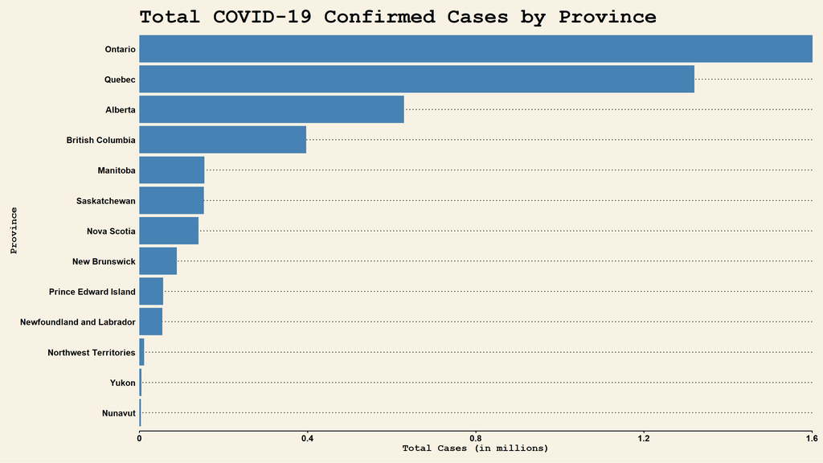

```r
latest_date <- tail(names(confirmed_cleaned), 1)
confirmed_latest <- confirmed_cleaned %>%
  select(`Province/State`, `Country/Region`, !!latest_date) %>%
  rename(Total_Cases = !!latest_date)

ggplot(confirmed_latest, aes(y = reorder(`Province/State`, Total_Cases), x = Total_Cases)) +
  geom_bar(stat = "identity", fill = "steelblue") +
  labs(title = paste("Total COVID-19 Confirmed Cases by Province"),
       y = "Province",
       x = "Total Cases (in millions)") +
  theme_wsj() +
  theme(
    title = element_text(size = 24),
    axis.text = element_text(size = 12),
    axis.title = element_text(size = 14, face = "bold")
    ) +
  scale_x_continuous(labels = function(x) x / 1e6, expand = c(0, 0))
```

- Top3: Ontario, Quebec, Alberta

| **3.2 Total COVID-19 Death Cases by Province** |
| --- |

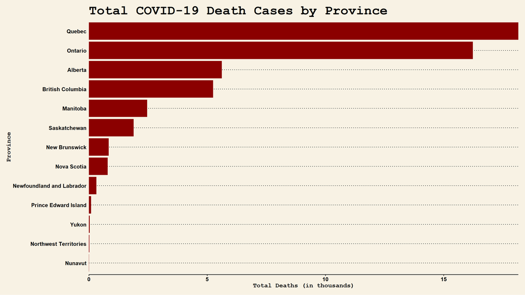

```r
latest_date_death <- tail(names(deaths_cleaned), 1)
deaths_latest <- deaths_cleaned %>%
  select(`Province/State`, `Country/Region`, !!latest_date_death) %>%
  rename(Total_Deaths = !!latest_date_death)

ggplot(deaths_latest, aes(y = reorder(`Province/State`, Total_Deaths), x = Total_Deaths)) +
  geom_bar(stat = "identity", fill = "darkred") +
  labs(title = paste("Total COVID-19 Death Cases by Province"),
       y = "Province",
       x = "Total Deaths (in thousands)") +
  theme_wsj() +
  theme(
    title = element_text(size = 24),
    axis.text = element_text(size = 12),
    axis.title = element_text(size = 14, face = "bold")
    ) +
  scale_x_continuous(labels = function(x) x / 1e3, expand = c(0, 0))
```

- Top3: Quebec, Ontario, Alberta

| **3.3 COVID-19 Fatality Rate by Province** |
| --- |

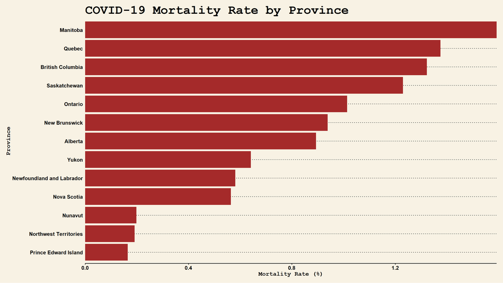

```r
combined_data <- left_join(confirmed_latest, deaths_latest, by = c("Province/State", "Country/Region"))
combined_data$Mortality_Rate <- (combined_data$Total_Deaths / combined_data$Total_Cases) * 100
mortality_data <- combined_data %>%
  select(`Province/State`, Mortality_Rate) %>%
  arrange(desc(Mortality_Rate))

ggplot(mortality_data, aes(y = reorder(`Province/State`, Mortality_Rate), x = Mortality_Rate)) +
  geom_bar(stat = "identity", fill = "brown") +
  labs(title = "COVID-19 Mortality Rate by Province",
       y = "Province",
       x = "Mortality Rate (%)") +
  theme_wsj() +
  theme(
    title = element_text(size = 24),
    axis.text = element_text(size = 12),
    axis.title = element_text(size = 14, face = "bold")
    ) +
  scale_x_continuous(expand = c(0, 0))
```

- Top3: Manitoba, Quebec, British Columbia

| **3.4 COVID-19 Infection Rate by Province** |
| --- |

2021 Population Data Source: https://www12.statcan.gc.ca/census-recensement/2021/dp-pd/prof/details/download-te

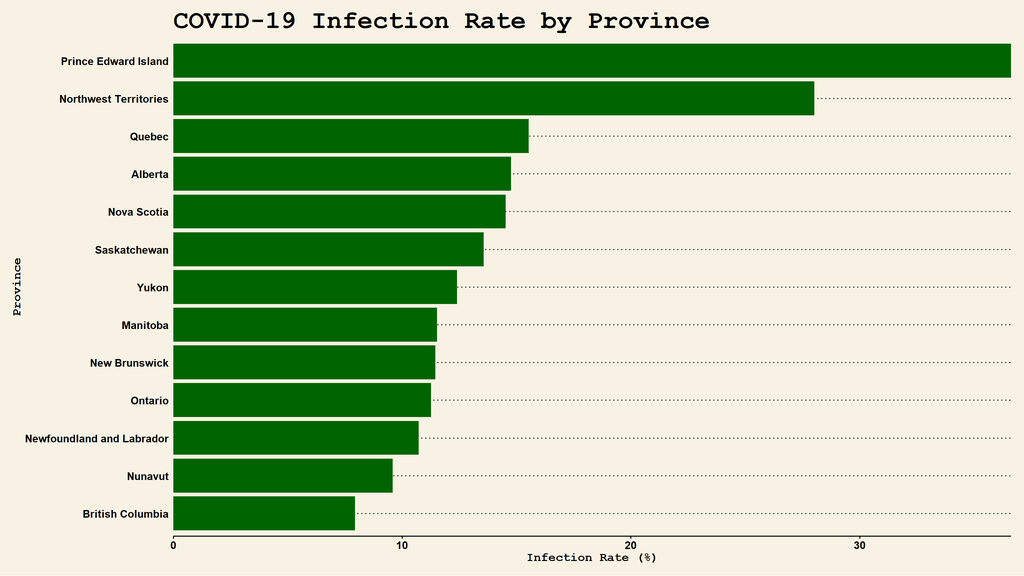

```r
population_data <- data.frame(
  "Province/State" = c("Ontario", "Quebec", "British Columbia", "Alberta", "Manitoba", "Saskatchewan", "Nova Scotia", "New Brunswick", "Newfoundland and Labrador", "Prince Edward Island", "Northwest Territories", "Yukon", "Nunavut"),
  Population_2021 = c(14223942, 8501833, 5000879, 4262635, 1342153, 1132505, 969383, 775610, 510550, 154331, 41070, 40232, 36858)
)
names(confirmed_latest)[names(confirmed_latest) == "Province/State"] <- "Province.State"

merged_data <- left_join(confirmed_latest, population_data, by = "Province.State")
merged_data$Infection_Rate <- (merged_data$Total_Cases / merged_data$Population_2021) * 100

ggplot(merged_data, aes(y = reorder(Province.State, Infection_Rate), x = Infection_Rate)) +
  geom_bar(stat = "identity", fill = "darkgreen") +
  labs(title = "COVID-19 Infection Rate by Province",
       y = "Province",
       x = "Infection Rate (%)") +
  theme_wsj() +
  theme(
    title = element_text(size = 24),
    axis.text = element_text(size = 12),
    axis.title = element_text(size = 14, face = "bold")
  ) +
  scale_x_continuous(expand = c(0, 0))
```

- Top3: Prince Edward Island, Northwest Territories, Quebec

| **3.5 Fatality Rate vs Infection Rate by Province** |
| --- |